# Simple Linear Regression

## Poverty and Graduation

```
##                   State Metropolitan.Residence White Graduates Poverty
## 1               Alabama                   55.4  71.3      79.9    14.6
## 2                Alaska                   65.6  70.8      90.6     8.3
## 3               Arizona                   88.2  87.7      83.8    13.3
## 4              Arkansas                   52.5  81.0      80.9    18.0
## 5            California                   94.4  77.5      81.1    12.8
## 6              Colorado                   84.5  90.2      88.7     9.4
## 7           Connecticut                   87.7  85.4      87.5     7.8
## 8              Delaware                   80.1  76.3      88.7     8.1
## 9  District of Columbia                  100.0  36.2      86.0    16.8
## 10              Florida                   89.3  80.6      84.7    12.1
## 11              Georgia                   71.6  67.5      85.1    12.1
## 12               Hawaii                   91.5  25.9      88.5    10.6
## 13                Idaho                   66.4  95.5      88.2    11.8
## 14             Illinois                   87.8  79.5      85.9    11.2
```

[output cut: 87 more lines]

## Poverty and Graduation

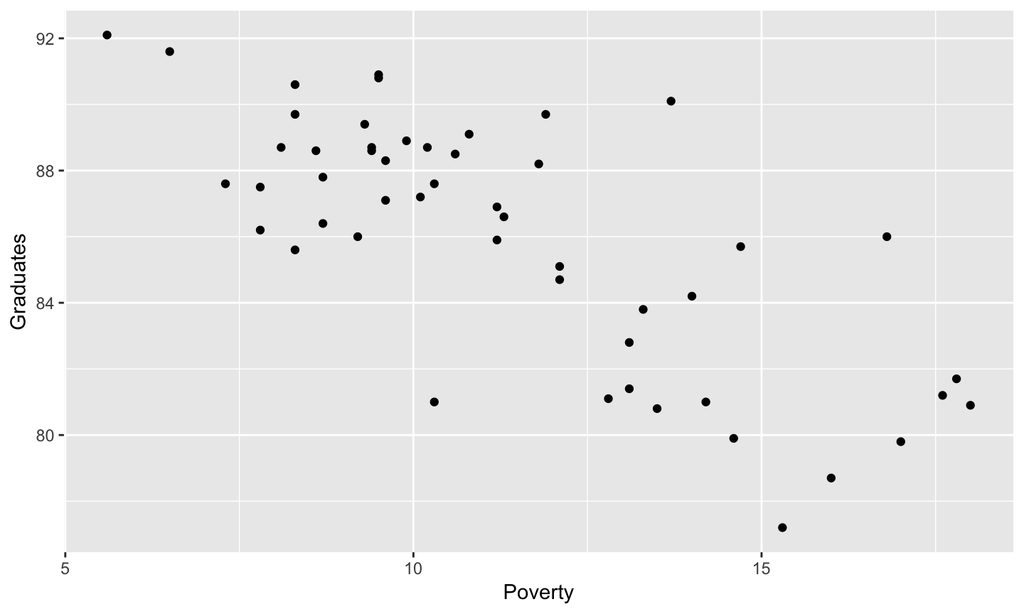

## Poverty and Graduation

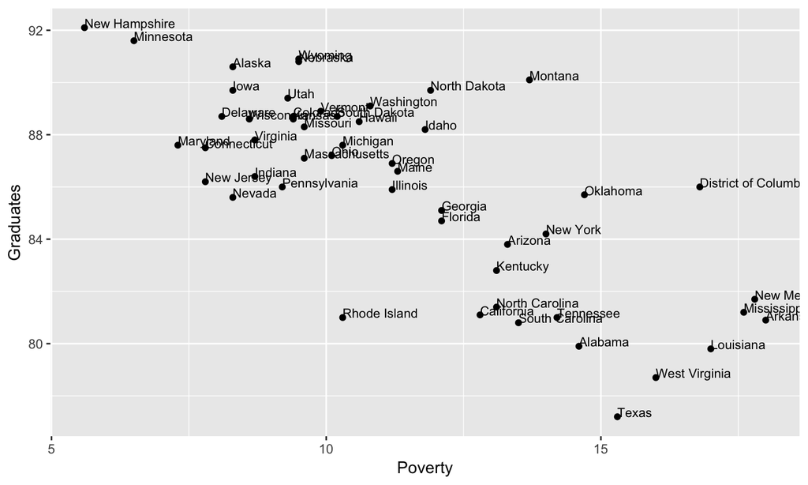

## Poverty and Graduation

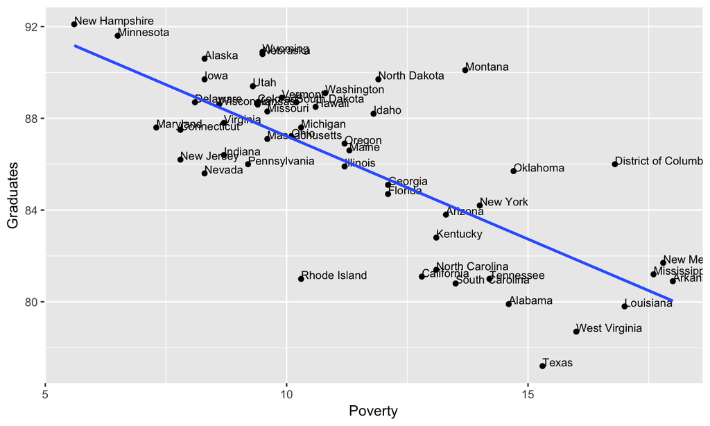

## The linear model

```r
cor(poverty$Graduates, poverty$Poverty)
```

```
## [1] -0.747
```

```r
lm(Graduates ~ Poverty, data = poverty)
```

```
##
## Call:
## lm(formula = Graduates ~ Poverty, data = poverty)
##
## Coefficients:
## (Intercept)      Poverty
##      96.202       -0.898
```

## Residual Plot

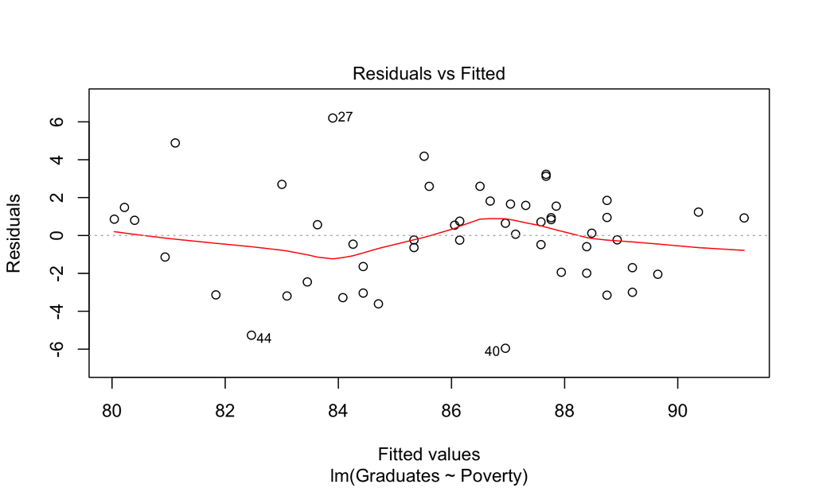

## Identification of Problem Types

Recall the following notation:

- \(G\): categorical variable with 2 groups
- \(H\): categorical variable with 3+ groups
- \(K\): continuous variable

For each of the following problems,

- identify the model type (e.g., \(K_1 \sim K_2\)),
- determine which type of problem it is (One Mean, One Proportion…, Multiple Proportions (Test of Independence))
- draw a sketch of an effective visualization and give the name of that type of plot,
- write the null and alternative hypotheses, and
- provide the named distribution (e.g., \(t(df = 22)\)) for the null distribution.

## Identification of Problem Types

1. The Survey of Study Habits and Attitudes (SSHA) is a psychological test that measures students' study habits and attitude toward school. Scores range from 0 to 200. The mean score for U.S. College students is about 115. A teacher suspects that older students have different attitudes toward school than the national average. She gives the SSHA to 25 randomly selected students who are at least 30 years old. The mean of these 25 scores is 118.6 and the standard deviation is about 30.
1. If you are a dog lover, perhaps having your dog along reduces the effect of stress. To examine the effect of pets in stressful situations, researchers recruited 45 women who said they were dog lovers. Fifteen subjects were randomly assigned to one of three groups to do a stressful task alone, with a good friend present, or with their dog present (each group had 15 subjects). The subject's heart rate during the task is one measure of the effect of stress. Can we believe that the heart rate of dog lovers is related to stress when working on a task alone, with a friend, or with a dog?